# Monitoring Media Narratives

April 2016

## Agenda

- Methodology Overview
- Getting Data
- Processing Data
- Searching Data
- Visualizing Data
- Anchorman (App)

## Don't you mean Social Media?

NO!

## Motivating Theory 1: Media Contagion

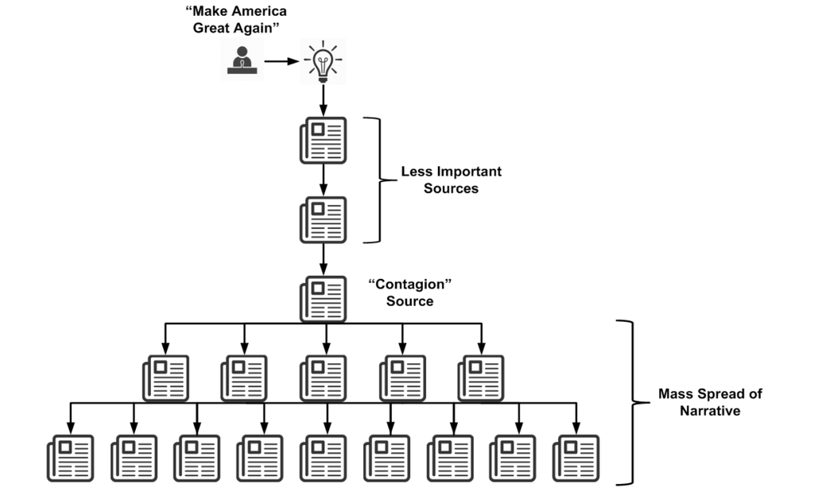

## Motivating Theory 2: Media "Telephone Game"

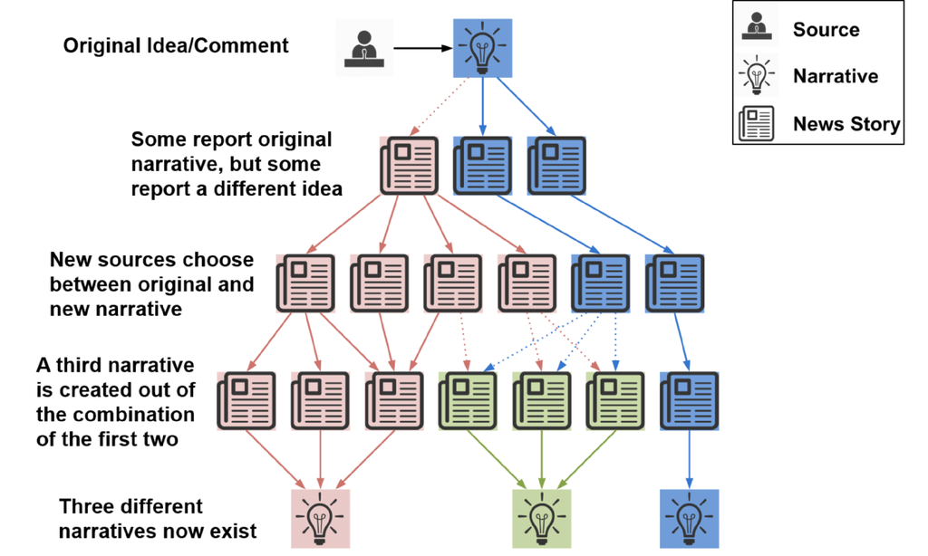

## Motivating Theory 2: Media "Telephone Game" Example

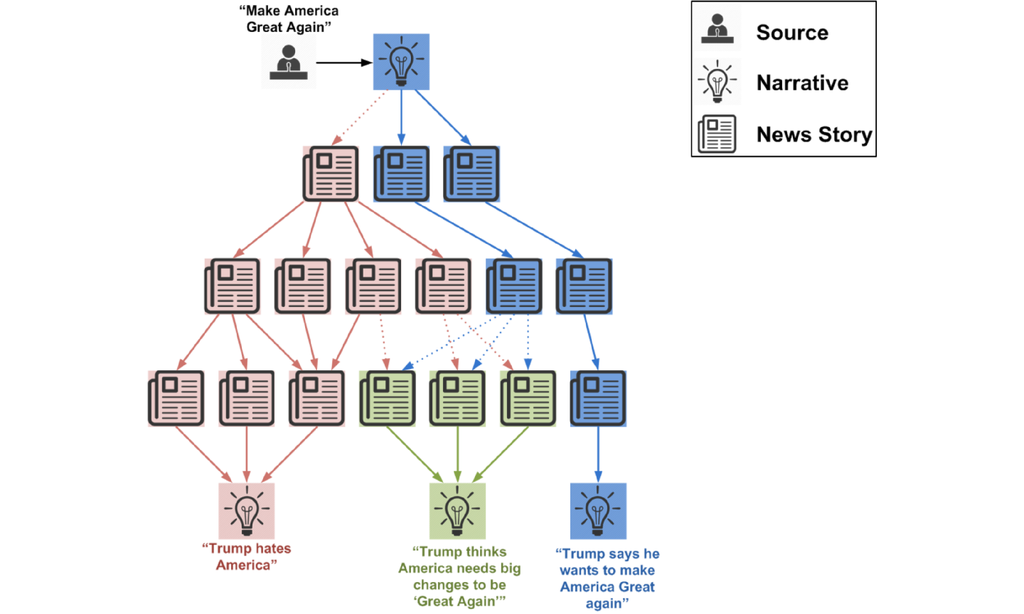

## The Goal

- Visualize Media Coverage of a Narrative Over Time
- Subset, Search, and Explore Article Text
  - Find "Similar" Words and Phrases

## Methodology Overview

[figure not shown]

## Data Scoping

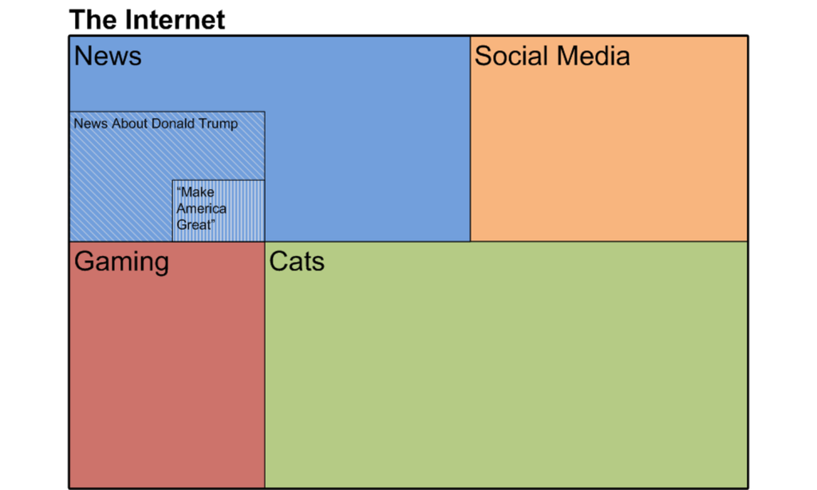

## Getting Data

There are 2 ways to get data:

- **Web Scraping**
  - Fully Customizable
  - Potentially Difficult
  - Frequent Monitoring and Rebuilding
  - Security Risks?
- **Web Aggregators**
  - User-Friendly APIs
  - Limited Data Sources
  - Money?
  - Security Risks?

## Web Scraping Example

Step 1: Find and Generate URLs of Index Pages (i.e., Search Results)

```r
main <- "https://www.donaldjtrump.com/press-releases/"
page.list<-paste(main, "P", seq(from=10, to=40, by=10), sep="")
page.list<-c("https://www.donaldjtrump.com/press-releases/", page.list)

page.list
```

```
## [1] "https://www.donaldjtrump.com/press-releases/"
## [2] "https://www.donaldjtrump.com/press-releases/P10"
## [3] "https://www.donaldjtrump.com/press-releases/P20"
## [4] "https://www.donaldjtrump.com/press-releases/P30"
## [5] "https://www.donaldjtrump.com/press-releases/P40"
```

## Web Scraping Example

Step 2: Find URLs of Specific Press Releases

```r
press.list<-list()
for(i in 1:length(page.list)){
  page<-read_html(page.list[i])
  sections <- page %>%
    html_nodes("h2")
  websites <- as.vector(xpathSApply(htmlParse(sections), "//a/@href"))
  press.list[[i]]<-websites
}

press.releases<-unlist(press.list)

press.releases[c(1,2)]
```

```
## [1] "https://www.donaldjtrump.com/press-releases/rnc-and-donald-j.-trump-campaign-announce-joint-agreement"
## [2] "https://www.donaldjtrump.com/press-releases/donald-j.-trump-files-personal-financial-disclosure-form-with-the-federal-e"
```

## Web Scraping Example

Step 3: Scrape Press Releases

```r
process.releases.function<-function(press.release){
  website<-press.release
  grabbed.text<-read_html(website)

  #Extract and format publish date
  date<-grabbed.text %>%
    html_nodes("h6") %>%
    html_text

  date.1<-date
  date.2<-gsub("-", "", date.1)
  date.3<-str_trim(date.2)
  date.4<-gsub(",", "", date.3)
  published<-as.Date(date.4, format="%B %d %Y")
  ...
```

## Web Scraping Example

Step 3: Scrape Press Releases

```r
  ...
  source.name<-"TrumpCampaign"
  author<-"Trump Campaign"

  url<-website
  text<- grabbed.text %>%
    html_nodes("p") %>%
    html_text
  title<- grabbed.text %>%
    html_nodes("h1") %>%
    html_text
  text<-paste(text, collapse=" ")
return(cbind(published, source.name, author, url, title, text))
}
```

## Web Aggregator Example

Step 1: Define Starting URL (provided by aggregator)

```r
library(XML)
library(RCurl)
library(rvest)
```

```r
Source<-"FoxNews"

start.url<-'https://webhose.io/search?token=
84921daf-6173-40a7-9aed-648870f92b2f&format=
xml&q=Donald%20Trump%20site%3Ahuffingtonpost.
com%20(site_type%3Anews)&ts=1458938841170'
```

## Web Aggregator Example

Step 2: Define Processing Function

```r
process.post.function<-function(post){
  source.name<-Source
  author<-post %>%
    html_node("author") %>%
    html_text
  url<-post %>%
    html_node("url") %>%
    html_text
  article.raw.date<-post %>%
    html_node("published") %>%
    html_text
  ...
```

## Web Aggregator Example

Step 2: Define Processing Function

```r
  ...
  published<-as.Date(strsplit(article.raw.date, "T")[[1]][1])
  title<-post %>%
    html_node("title") %>%
    html_text
  text<-post %>%
    html_node("text") %>%
    html_text
  return(cbind(published, source.name, author, url, title, text))
}
```

## Web Aggregator Example

Step 3: Read in and Process the First 100 Articles

```r
counter<-1
post.index<-list()

file.data<-getURL(start.url)
xml.object<-read_html(file.data)

posts<-xml.object %>%
  html_nodes("post")

post.index[[counter]]<-do.call("rbind",lapply(posts,
                                              process.post.function))
```

## Web Aggregator Example

Step 4: Find URLs for Remaining Articles

```r
posts.remaining<-xml.object %>%
  html_node("moreresultsavailable") %>%
  html_text

next.list<-xml.object %>%
  html_nodes("next") %>%
  html_text

new.url<-paste("https://webhose.io", next.list, sep="")
```

## Web Aggregator Example

Step 5: Iterate While Articles Remain

```r
while(posts.remaining > 0){
  counter<- counter + 1
  file.data<-getURL(new.url)
  xml.object<-read_html(file.data)

  posts<-xml.object %>%
    html_nodes("post")
  post.index[[counter]]<-do.call("rbind",
                                 lapply(posts, process.post.function))

  posts.remaining<-xml.object %>%
    html_node("moreresultsavailable") %>%
    html_text
  next.list<-xml.object %>%
    html_nodes("next") %>%
    html_text

  new.url<-paste("https://webhose.io", next.list, sep="")
}
```

## Processing Data: What do we Need?

- **Ngram List** (for searching)
  - Example Sentence: "Donald Trump is running for president"
  - bi-gram: Donald Trump; Trump is; is running; running for; for president
  - tri-gram: Donald Trump is; Trump is running; is running for; running for president
  - quad-gram(?): Donald Trump is running; Trump is running for; is running for president
- **Article Index** (for visualizing)

## Processing Data: Ngram List

Process Article Text into Unique Ngrams (from length 2 to 10):

```r
ngram.function<-function(article.text){
  words.processed<-preprocess(article.text, case="lower",
                              split.at.punct=TRUE)
  word.block<-concat(words.processed)
  source <- VectorSource(word.block)
  corpus <- Corpus(source)
  Tokenizer <- function(x){
    NGramTokenizer(x, Weka_control(min = 2, max = 10))
  }
  tdm <- TermDocumentMatrix(corpus,
                            control = list(tokenize = Tokenizer,
                                           removePunctuation = TRUE))
  ngram.vector<-as.vector(tdm$dimnames$Terms)
  return(ngram.vector)
}
```

## Processing Data: Article Index

Load and Combine Scraped Articles:

```r
load('FoxNewsArticleIndex.rdata')
load('TrumpCampaignReleaseIndex.rdata')
...

ArticleIndex <- rbind(df, df.sub)
save(ArticleIndex, file='ArticleIndex.rdata')
```

## Interacting with Data

- Searching
  - Text-Based Similarity
  - Semantic-Based Similarity
- Visualizing
  - Subsetting
  - Interacting

## Searching Data: Text-Similarity Method

Logic:

- Input = Phrase, Threshold
  - Filter to ngrams with length = length of phrase (+ or - 1)
  - Score similarity of phrase and filtered ngrams (Jaro-Winkler)
- Output = phrases with similarity > threshold

## Searching Data: Text-Similarity Method

Code:

```r
  phrase = 'ban muslims'
  phrase.words<-length(unlist(strsplit(phrase," ")))
  threshold<- input$matchSlider

  candidatePhrase <- Ngram.list.rollup[Ngram.list.rollup$len ==
                                         phrase.words + 1 |
                                         Ngram.list.rollup$len ==
                                         phrase.words - 1 |
                                         Ngram.list.rollup$len ==
                                         phrase.words,]
  candidatePhrase$distCalc <-stringdist(phrase, candidatePhrase$x,
                                        method="jw")
  Close.Matches<-candidatePhrase[candidatePhrase$distCalc < threshold,]

  colnames(Close.Matches) <- c("Phrase", "Length", "JaroWinklerDistance")
```

## Searching Data: Text-Similarity Method

Example:

```r
library(stringdist)

searchPhrase <- 'ban muslims'

matchPhrases <- c('bar muslims', 'forbid muslims', 'restrict muslims')

stringdist(searchPhrase, matchPhrases, method="jw")
```

```
## [1] 0.06060606 0.29076479 0.42424242
```

## Searching Data: Semantic Matching

Logic:

- Input = Phrase
  - Look for synonyms for each word in phrase
  - Create all unique combinations of synonyms
  - Search (exact match) for synonym phrases in ngram list
- Output = synonym phrases that appear in the data

## Searching Data: Semantic Matching

Code (pt1):

```r
require(qdap)

phrase <- 'ban muslims'
temp <- list()
for(i in 1:length(words)) {
  if(is.null(synonyms(words[i]))) {
    temp[[i]] <- words[i]
  } else{
    temp[[i]] <- c(words[i],synonyms(words[i], return.list=FALSE))
  }
}

test <- expand.grid(temp[[1]], temp[[2]])
```

## Searching Data: Semantic Matching

Code (pt2):

```r
temp <- NULL
possiblePhrases <- NULL
for(i in 1:nrow(test)){
  temp <- NULL
  for (j in 1:ncol(test)) {
    temp <- paste(temp, as.character(test[i,j]))
    temp <- sub("^\\s+", "", temp)
  }
  possiblePhrases <- c(possiblePhrases, temp)
}

searchCandidates <- Ngram.list.rollup[which(Ngram.list.rollup$len ==
                                              length(words)),]
```

## Searching Data: Semantic Matching

Code (pt3):

```r
userPhrases <- NULL
for(i in 1:length(possiblePhrases)){
  if(length(searchCandidates$x[searchCandidates$x ==
                               possiblePhrases[i]]) == 0) {

  } else {
    userPhrases <- c(userPhrases, possiblePhrases[i])
  }
  print(paste('searching', i, 'of', length(possiblePhrases)))
}
```

## Searching Data: Semantic Matching

Example:

```r
searchPhrase <- 'ban muslims'
words <- unlist(strsplit(searchPhrase," "))
matchPhrases <- c('bar muslims',
                  'forbid muslims',
                  'restrict muslims')
temp <- list()
for(i in 1:length(words)) {
  if(is.null(synonyms(words[i]))) {
    temp[[i]] <- words[i]
  } else{
    temp[[i]] <- c(words[i],synonyms(words[i], return.list=FALSE))
  }
}
test <- expand.grid(temp[[1]], temp[[2]])
test[2,]
```

```
##     Var1    Var2
## 2 banish muslims
```

## Searching Data: Semantic Matching

Example:

```r
temp <- NULL
possiblePhrases <- NULL
for(i in 1:nrow(test)){
  temp <- NULL
  for (j in 1:ncol(test)) {
    temp <- paste(temp, as.character(test[i,j]))
    temp <- sub("^\\s+", "", temp)
  }
  possiblePhrases <- c(possiblePhrases, temp)
}

possiblePhrases[2:4]
```

```
## [1] "banish muslims" "bar muslims"    "black muslims"
```

## Searching Data: Semantic Matching

Example:

```r
userPhrases <- NULL
for(i in 1:length(possiblePhrases)){
  if(length(matchPhrases[matchPhrases ==
                         possiblePhrases[i]]) == 0) {

  } else {
    userPhrases <- c(userPhrases, possiblePhrases[i])
  }
  #print(paste('searching', i, 'of', length(possiblePhrases)))
}

userPhrases
```

```
## [1] "bar muslims"      "forbid muslims"   "restrict muslims"
```

## Visualizing Data

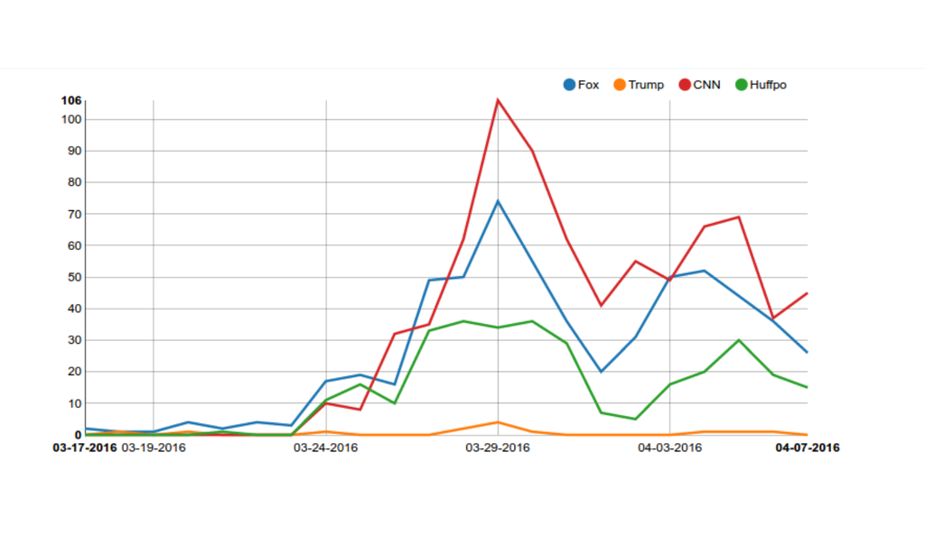

## Visualizing Data

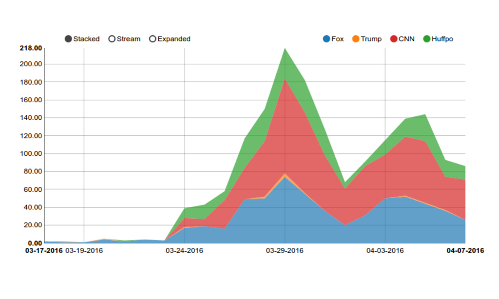

## Visualizing Data

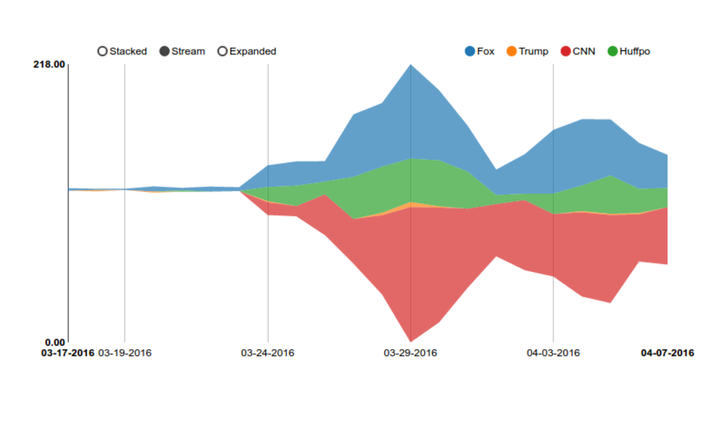

## Visualizing Data

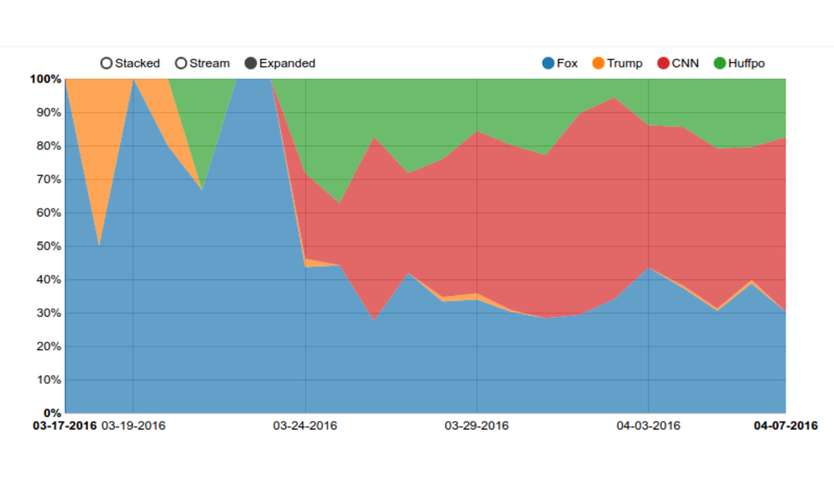

## Visualizing Data

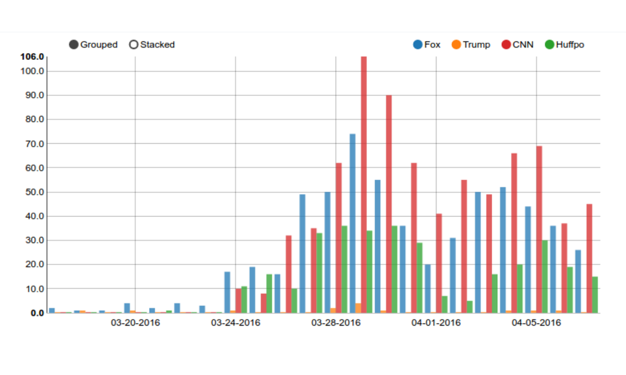

## Visualizing Data

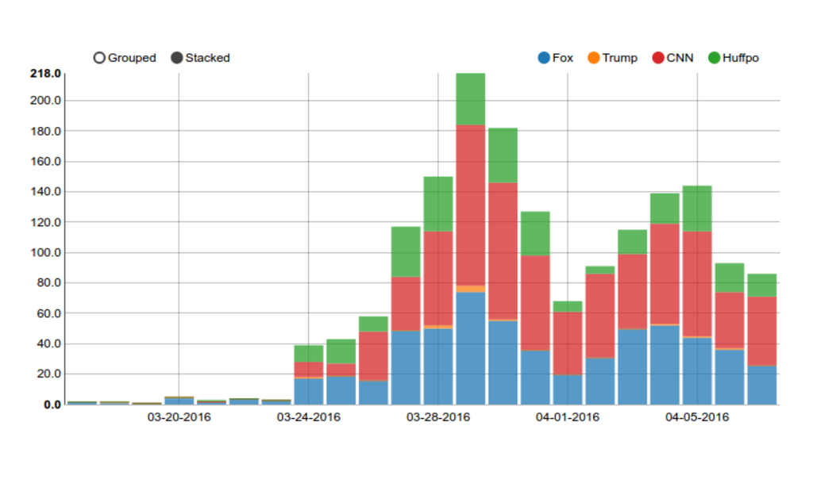

## App Demo

[Anchorman](http://ec2-54-152-99-224.compute-1.amazonaws.com/shiny/AnchormanLite)